# Stats 20, 22W – Homework 1

Joanne Qiu – 405369627

01/10/22

## Question 1

### (a)

“**Sometimes you have to make the hardest climb to see the most beautiful sunrise.** I read that once on an old lady’s decorative pillow, but it is really how I feel today. I’ve climbed a very weird and rocky mountain, and it was a pain in the ass, and my legs are tired, and I’m starving. But *the sun is rising over a sea of love and waffles and possibility.* So *I’m just gonna relax and take a deep breath and enjoy this view for as long as I possibly can*.” – Leslie Knope (from *Parks and Recreation*)

### (b)

| Homework | Midterm | Final Exam | Final Project |
| --- | --- | --- | --- |
| 18% | 30% | 40% | 12% |

### (c)

- 2021
  - Fall
    - Physics 1B: Physics for Scientists and Engineers: Oscillations, Waves, Electric and Magnetic Fields
    - Program in Computing 10A: Introduction to Programming
    - Mathematics 115AH: Linear Algebra (Honors)
    - Mathematics 61: Introduction to Discrete Structures
- 2022
  - Winter
    - Statistics 20: Introduction to Statistical Programming with R
    - Program in Computing 10B: Intermediate Programming
    - Program in Computing 16A: Python with Applications I
    - Mathematics 151AH: Numerical Analysis Part 1 (Honors)
    - Statistics 285: Seminar: Computing for Statistics
    - Honors Collegium 101C: UCLA Undergraduate Journal for Humanities and Social Sciences

### (d)

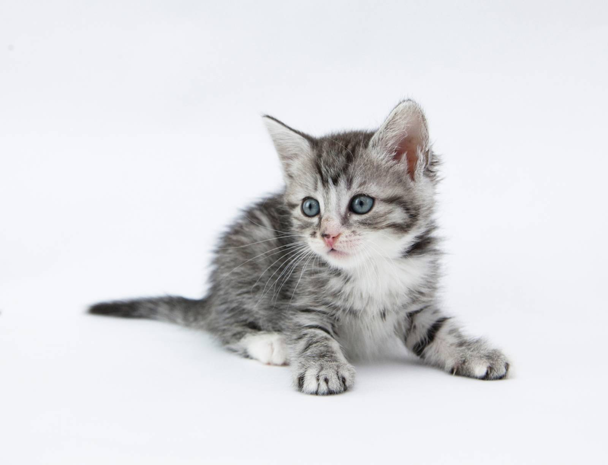

Kitten image from: https://time.com/5555118/kitten-cannibalism-usda/

## Question 2

### (a)

In the first video, the father asked his children to create instructions of making peanut butter and jelly sandwiches. By editing their recipes, the kids realized the necessity of being specific and clear. In the second video, the two people couldn’t understand what “Fold in cheese” means on the recipe, so they couldn’t continue cooking. Coding is like creating instructions for computer to work. Every step is important. If the logic of our codes is not correct or clear, or there are problematic gaps or error amid the codes, the computer won’t be able to understand what we want it to do.

### (b)

Take two slices of white bread. Get a butter knife and cut a small cube of butter. With the knife, spread the butter on one side of each slice of bread. Get two slices of cheddar cheese. Put the two slices of cheddar cheese on the butter side of one slice of bread. Top the other slice of bread with the butter side faced the cheddar cheese. Put the two slices of bread together into a microwave. Set up the microwave for two minutes. After two minutes, open the microwave and check if the cheese is melting. If it is melting, the grilled cheese sandwich is ready. If it is not, put it back into the microwave and heat it for another two minutes.

## Question 3

### (a)

```r
w <- 6
x <- 8
y <- 16
z <- 5
(w^x) / (y^z)
```

```
## [1] 1.601807
```

```r
p <- 101
q <- -8
l <- 7
p^(q / l)
```

```
## [1] 0.005120908
```

```r
a <- 8
b <- 3
c <- 4
d <- 2
e <- -1
a + (b * pi) - b + ((c / d) * e)
```

```
## [1] 12.42478
```

1. The result of (`w` to `x`) over (`y` to `z`) is (1.679616^{6}) / (1.048576^{6}) = 1.6018066.
2. The result of `p` to (`q` over `l`) is 101^(-1.1428571) = 0.0051209.
3. The result of `a` + (`b` * `pi`) - `b` + ((`c` / `d`) * `e`) is 8 + (3 * 3.1415927) - 3 + (2 * -1) = 12.424778.

### (b)

```r
x <- 54
y <- 2
log(x, base = y)
```

```
## [1] 5.754888
```

```r
p <- 2
exp(exp(sqrt(p)))
```

```
## [1] 61.14514
```

```r
a <- exp(pi)
b <- exp(-pi)
c <- 2
(a + b) / c
```

```
## [1] 11.59195
```

1. The result of log`x` based `y` is log(54, base = 2) = 5.7548875.
2. The result of the exponential of the exponential of the square root of `p` is exp(exp(sqrt(`p`))) = 61.1451398.
3. The result of the sum of the exponential of `pi` and the exponential of `-pi` over `c` is (23.1406926 + 0.0432139) / 2 = 11.5919533.

### (c)

```r
x <- 25
y <- 119
y %/% x
```

```
## [1] 4
```

```r
y %% x
```

```
## [1] 19
```

1. The number of times that `x` goes into `y` is 119 %/% 25 = 4.
2. The remainder after dividing `y` by `x` is 119 %% 25 = 19.

## Question 4

### (a)

```r
r <- 1
vol_1 <- (4 / 3) * pi * r^3

r <- 4
vol_4 <- (4 / 3) * pi * r^3
```

1. The volume of a sphere of radius `r` = 1 is 4.1887902.
2. The volume of a sphere of radius `r` = 4 is 268.0825731.

### (b)

```r
vol_sphere <- function(r = 1) {
  (4 / 3) * pi * r^3
}
```

### (c)

```r
vol_sphere()
```

```
## [1] 4.18879
```

```r
vol_sphere(4)
```

```
## [1] 268.0826
```

1. `vol_sphere()` = 4.1887902 and `vol_1` = 4.1887902, so the output of `vol_sphere()` appears to be the same value as `vol_1`.
2. `vol_sphere(4)` = 268.0825731 and `vol_4` = 268.0825731, so the output of vol_sphere(4) appears to be the same value as `vol_4`.

## Question 5

### (a)

```r
# x: the number of successes
# n: the number of trials
# p0: the hypothesized population proportion
z_prop <- function(x, n, p0) {
  p_hat = x / n # The sample proportion is the ratio of the number of successes to the number of trials

  p_diff = p_hat - p0 # the difference of the proportions
  sd = sqrt(p0 * (1 - p0) / n) # standard deviation

  p_diff / sd
}
```

### (b)

```r
# x = 10
# n = 13
# p0 = 0.6
z_prop(10, 13, 0.6)
```

```
## [1] 1.245505
```

### (c)

Since 1.2455047 is smaller than 1.96 (alpha = 0.05), we fail to reject the null hypothesis (p = 0.6) and conclude that we do not have enough evidence to state that 60% of residents in the city of Pawnee, Indiana, don’t prefer waffles over pancakes.

### (d)

```r
# x = 30
# n = 39
# p0 = 0.6
z_prop(30, 39, 0.6)
```

```
## [1] 2.157277
```

In this case, `n` increases and `p0` doesn’t change, so the standard deviation decreases, which results in an increasing z-statistics.

## Question 6

### (a)

```r
lease_calc <- function(msrp, price, down, n = 36, res = 0.6, mf = 0.001, tax = 0.095) {
  cost_cap <- price - down # capitalized cost
  value_res <- msrp * res # residual value
  depre_mth <- (cost_cap - value_res) / n # monthly depreciation
  fin_chg_mth <- (cost_cap + value_res) * mf # montly finance charge
  sub_total <- depre_mth + fin_chg_mth # sub-total
  sub_total * (1 + tax) # total
}
```

### (b)

```r
lease_calc(31495, 29895, 2500, 36, 0.52, 0.0016, 0.095)
```

```
## [1] 411.8079
```

## Question 7

### (a)

Start with the coin with the highest value and go down one by one. 2 * 25 = 50 > 47, so we need one quarter. Then, 47 - 25 = 22. Since 3 * 10 = 30 > 22, we need two dimes. Now, 22 - 20 = 2, which means we don’t need nickels and instead we need two pennies. At last, the minimum number of coins required to equal 47 cents is 1 + 2 + 2 = 5.

### (b)

```
FUNCTION: get_minimum_coins
INPUT:    n, an arbitrary number of cents
OUTPUT:   an integer value of the minimum number of coins required to equal n cents.

total <- 0
total <- the integer part of n cents divided by quarter
rmd <- the remainder cents after the previous division
total <- total + the integer part of rmd divided by dime
rmd <- the remainder cents after the previous division
total <- total + the integer part of rmd divided by nickels
rmd <- the remainder cents after the previous division
total <- total + the integer part of rmd divided by pennies
total
```

### (c)

```r
get_minimum_coins <- function(cents) {
  total <- 0
  total <- cents %/% 25
  rmd <- cents %% 25
  total <- total + rmd %/% 10
  rmd <- rmd %% 10
  total <- total + rmd %/% 5
  rmd <- rmd %% 5
  total <- total + rmd %/% 1
  total
}
```

### (d)

```r
get_minimum_coins(31)
```

```
## [1] 3
```

```r
get_minimum_coins(48)
```

```
## [1] 6
```

```r
get_minimum_coins(139)
```

```
## [1] 10
```

1. The minimum number of coins required to equal 31 cents is 3.
2. The minimum number of coins required to equal 48 cents is 6.
3. The minimum number of coins required to equal 139 cents is 10.

### (e)

```r
get_minimum_coins(99)
```

```
## [1] 9
```

```r
get_minimum_coins(94)
```

```
## [1] 9
```

The biggest number of quarter we can get is 3 since 4 * 25 = 100 is not less than 100. Then, the biggest number of dimes we can get is 2 since 3 * 10 = 30 will contain a quarter. The biggest number of nickels we can get is 1 since 2 * 5 = 10 will be a dime. The biggest number of pennies we can get is 4 since 5 * 1 = 5 will be a nickel. Then, we notice that 99 - 3 * 25 = 24 is the most cents left after we have 3 quarters. 24 contains 2 dimes and 4 pennies. Thus, the most number of coins is 9. By observation, we can also change one dime to one nickel to remain 9 coins. In this case, the total of cents is 10 + 5 + 4 + 75 = 94. Therefore, 99 and 94 are the two number of cents that require the most coins.

## Question 8

```r
x <- 3
y <- 4
exp1 <- function() {
  x^y
}
exp2 <- function(x = 2) {
  x^y
}
exp_y <- function(x) {
  function(y) {
    x^y
  }
}
exp_y()
```

```
## function(y) {
##     x^y
##   }
## <environment: 0x140bedab0>
```

### (a)

The object in the default argument is in the local environment, so it will take precedence over the objects in the global environment. Thus, `exp1()` takes `x` = 3 whereas `exp2()` takes `x` = 2.

### (b)

`exp_y()` has its name and body. `function(y)` is a part of `exp_y`’s body and has its definition, so the definition of `exp_y()` does not have any error. `exp_y()` won’t print a numeric value unless it takes a second argument for y and command `function(y)`. In this case, `function(y)` is a subsidiary function inside `exp_y()`.

### (c)

```r
exp_y <- function(x, y) {
  x^y
}

exp_y(15, 3) # calculate the third power of fifteen
```

```
## [1] 3375
```